[figure not shown]

# TP2 : Enregister une modification.

**Objectifs :**

- Enregistrer une première modification.
- Visualiser/Naviguer dans son historique.

## 1. Ajouter une nouvelle fonctionnalité au parser

Nous allons ajouter la possibilité de mettre des lignes horizontales dans notre parser markdown.

Dans un premier temps, assurez vous de commencer le TP au bon endroit, pour cela utilisez la commande :

```bash
git checkout -b tp2 tp2-start
```

Nous verrons en détail au prochain cours ce que fait cette commande.

--

Dans un premier temps, dans le répertoire `converter/tests/features` ajouter deux fichiers :

- `horizontal_line.md`
- `horizontal_line.html`

Dans le premier ajouter :

```bash
---
```

Et dans le second :

```html
<hr/>
```

Si vous relancez les tests, vous verrez qu'ils ne passent plus :

```bash
npm run test
...
1 passing
1 failing
...
```

C'est normal, nous n'avons pas ajouté le nécessaire dans notre parser, pour celà, ouvrez le fichier `markdown.js` et ajoutez :

```html
 var parseHorizontaleLine = function(str) {
  var horizontalRegExp = /^(?:([\*\-_] ?)+)\1\1$/gm;
  var stra = [];
  while ((stra = horizontalRegExp.exec(str)) !== null) {
    str = str.replace(stra[0], '\n<hr/>\n');
  }
  return str;
 }
```

Puis ajouter l'appel à cette fonction dans la fonction parse

```javascript
str = parseHorizontaleLine(str);
```

Relancer les tests :

```bash
npm run test

parse() features testsuite
    ✓ h1
    ✓ horizontal_line
2 passing (10ms)
```

Nous venons donc d'ajouter une nouvelle fonctionnalité à notre parser, nous allons maintenant pouvoir la versionner dans git.

Si vous voulez tester en live, vous pouvez lancer le serveur `npm run dev` et allez [ici](http://localhost:8000).

## 2. Votre premier commit avec la ligne de commande.

Vous devez vous assurer d'être dans le répertoire du projet avant d'éxécuter les commandes.

- Vérifier l'état de git :

```bash
Correction
$ git status
On branch master
Your branch is up-to-date with 'origin/master'.
Changes not staged for commit:
  (use "git add ..." to update what will be committed)
  (use "git checkout -- ..." to discard changes in working directory)

    modified:   converter/markdown.js

Untracked files:
  (use "git add ..." to include in what will be committed)

    converter/tests/features/horizontal_line.html
    converter/tests/features/horizontal_line.md

no changes added to commit (use "git add" and/or "git commit -a")
```

- Ajouter les nouveaux fichiers :

```bash
Correction
$ git add converter/tests/features
```

- Vérifier que ces fichiers ont été ajouté :

```bash
Correction
$ git status
On branch master
Your branch is up-to-date with 'origin/master'.
Changes to be committed:
  (use "git reset HEAD ..." to unstage)

    new file:   converter/tests/features/horizontal_line.html
    new file:   converter/tests/features/horizontal_line.md

Changes not staged for commit:
  (use "git add ..." to update what will be committed)
  (use "git checkout -- ..." to discard changes in working directory)

    modified:   converter/markdown.js
```

- Visualiser les modifications sur le fichier markdown

```html
Correction
$ git diff
diff --git a/converter/markdown.js b/converter/markdown.js
index 7b21365..af92788 100644
--- a/converter/markdown.js
+++ b/converter/markdown.js
@@ -8,10 +8,20 @@
    return str;
  }

+ var parseHorizontaleLine = function(str) {
+  var horizontalRegExp = /^(?:([\*\-_] ?)+)\1\1$/gm;
+  var stra = [];
+  while ((stra = horizontalRegExp.exec(str)) !== null) {
+    str = str.replace(stra[0], '\n\n');
+  }
+  return str;
+ }
+
 var markdown = {
   parse: function (str, strict) {
     'use strict';
     str = parseHeadline(str);
+    str = parseHorizontaleLine(str);
     return str;
   }
 };
```

- Ajouter le dernier fichier

```bash
Correction
$ git add -u //ajoute tous les fichiers connus
```

- Faites votre premier commit

```bash
Correction
$ git commit -m "add horizontal line to parser"
```

- Visualiser le contenu de votre dernier commit

```bash
Correction
$ git show
commit b654ff9c4790d7f3db7328bb7657f4fc2c857a62
Author: sabativi
Date:   Mon Jul 20 14:31:17 2015 +0200

    add horizontal line to parser

diff --git a/converter/markdown.js b/converter/markdown.js
index 7b21365..af92788 100644
--- a/converter/markdown.js
+++ b/converter/markdown.js
@@ -8,10 +8,20 @@
    return str;
  }

+ var parseHorizontaleLine = function(str) {
+  var horizontalRegExp = /^(?:([\*\-_] ?)+)\1\1$/gm;
+  var stra = [];
+  while ((stra = horizontalRegExp.exec(str)) !== null) {
+    str = str.replace(stra[0], '\n\n');
+  }
+  return str;
+ }
+
 var markdown = {
   parse: function (str, strict) {
     'use strict';
     str = parseHeadline(str);
+    str = parseHorizontaleLine(str);
     return str;
   }
 };
diff --git a/converter/tests/features/horizontal_line.html b/converter/tests/features/horizontal_line.html
new file mode 100644
index 0000000..e2c5e31
--- /dev/null
+++ b/converter/tests/features/horizontal_line.html
@@ -0,0 +1 @@
+
\ No newline at end of file
diff --git a/converter/tests/features/horizontal_line.md b/converter/tests/features/horizontal_line.md
new file mode 100644
index 0000000..73b314f
--- /dev/null
+++ b/converter/tests/features/horizontal_line.md
@@ -0,0 +1 @@
+---
\ No newline at end of file
```

- Visualiser les changements de votre historique

```bash
Correction
$ git log
commit 1a4c66009da916bcf46e8fa93689212416c8d793
Author: sabativi
Date:   Mon Jul 20 14:26:52 2015 +0200

    add horizontal line to parser

commit 5d78b73cbff0b3c650825f46d6c753b657735e4d
Author: Victor Sabatier
Date:   Wed Jul 15 15:03:41 2015 +0200

    Initial commit with add headlines parser
```

Ou avec une version abregée et un peu plus jolie :), que vous pouvez ajouter dans votre config.

```bash
$ git log --graph --decorate --pretty=oneline --abbrev-commit
* b654ff9 (HEAD, master) add horizontal line to parser
* 5d78b73 (tag: tp2-start, origin/master, origin/HEAD) Initial commit with add headlines parser
```

## 3. Votre premier commit avec l'interface graphique

Nous allons refaire les étapes précédentes avec l'interface graphique.

Pour celà, nous allons revenir en arrière dans l'historique :

```bash
$ git reset HEAD^ // nous verrons plus tard ce que fait cette commande
```

Pour vérifier :

```bash
$ git status
On branch master
Your branch is up-to-date with 'origin/master'.
Changes not staged for commit:
  (use "git add ..." to update what will be committed)
  (use "git checkout -- ..." to discard changes in working directory)

    modified:   converter/markdown.js

Untracked files:
  (use "git add ..." to include in what will be committed)

    converter/tests/features/horizontal_line.html
    converter/tests/features/horizontal_line.md

no changes added to commit (use "git add" and/or "git commit -a")
```

Ouvrer l'interface graphique :

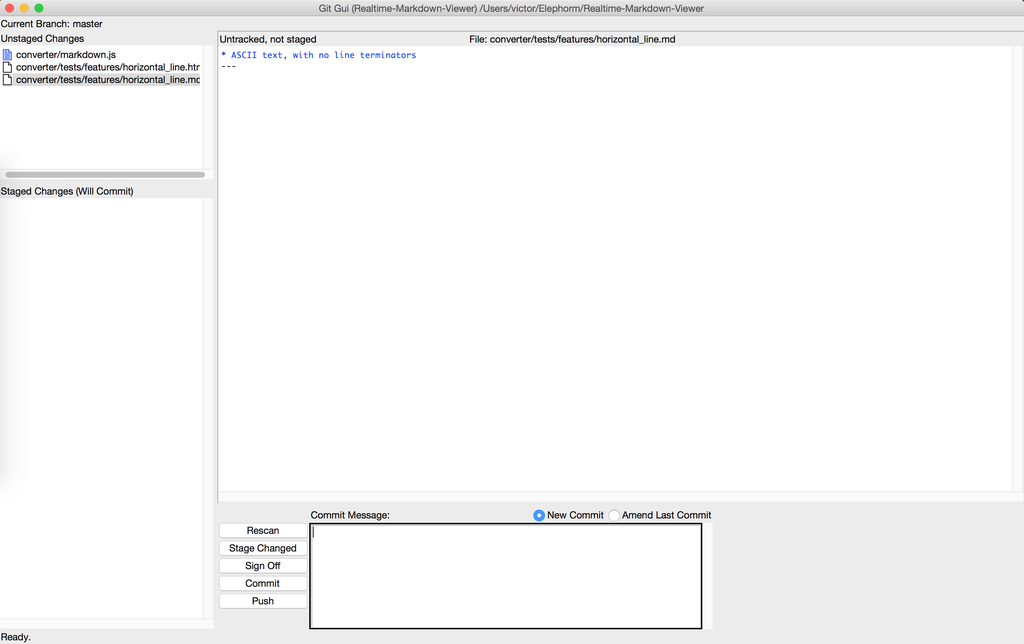

```bash
$ git gui
```

Ajouter les fichiers dans la staging area en cliquant sur les icones, puis rentrez le même message de commit que précédemment dans la zone prévue à cet effet :

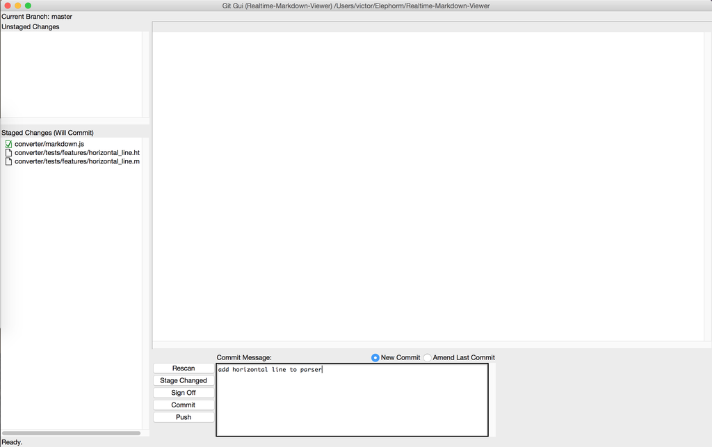

Valider en appuyant sur commit.

Retourner dans votre terminal et vérifier l'historique du projet :

```bash
$ git log
commit b654ff9c4790d7f3db7328bb7657f4fc2c857a62
Author: sabativi
Date:   Mon Jul 20 14:31:17 2015 +0200

    add horizontal line to parser

commit 5d78b73cbff0b3c650825f46d6c753b657735e4d
Author: Victor Sabatier
Date:   Wed Jul 15 15:03:41 2015 +0200

    Initial commit with add headlines parser
```

Notre historique est bien le même, sauf que notre dernier commit n'est pas le même. Il contient les mêmes modifications mais son `SHA1` est différent.

Pour preuve chez moi ( ça sera forcément différent chez vous ) :

- Premier commit : `1a4c6600`
- Deuxième commit : `b654ff9c`

Vous pouvez aussi visualiser votre historique avec `gitk` livré avec git :

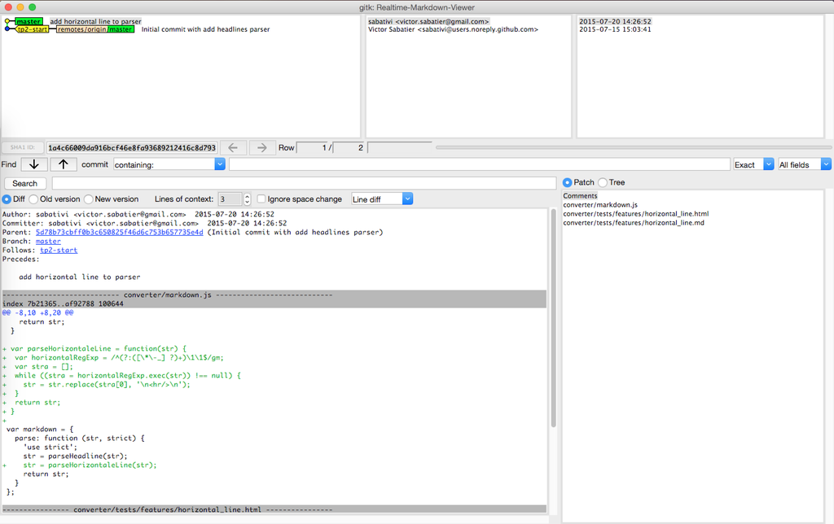

```bash
$ gitk
```

## 4. Et si on faisait deux commits au lieu d'un ?

Ici, nous souhaitons commiter séparemment les fichiers de tests, de la fonction du parser.

- Pour celà, nous allons (encore) revenir en arrière dans l'historique :

```bash
$ git reset HEAD^
```

- Ajouter le parser dans la staging area :

```bash
Correction
$ git add converter/markdown.js
```

- Finalement, nous préférons ajouter d'abord les fichiers de tests au premier commit, désindexer donc le fichier `markdown.js`:

```bash
Correction
$ git reset HEAD converter/markdown.js
    Unstaged changes after reset:
    M   converter/markdown.js
```

- Faites un premier commit avec les fichiers de tests :

```bash
Correction
$ git add converter/tests/features
$ git commit -m "add horizontal lines test"
```

- Puis ajouter le parser :

```bash
Correction
$ git commit -am "add horizontal lines in parser"
```

Vous pouvez vérifier que le nouveau SHA1 est bien différent des deux précédents.